# Understanding the basics of cancer subtyping tasks, the results will be reused for the current paper

Thuc Le

17 July 2017

# 1. Introduction: Identifying Breast Cancer Subtypes

Breast cancer is not a single disease and identifying breast cancer subtypes helps us understand the heteroginity of the disease and assists with the prognosis and design of personalised treatments. The IHC method groups patients into 3 subtypes using pathological markers: ER+, HER+, and triple negative.

Molecular subtyping provides a more comprehensive explanation of what and how the subtype develops. There are several approaches of subtyping breast cancer using gene expression data. However, the commonly accepted approaches are:

1. 4 intrinsic subtypes defined by Perou et al: Luminal A, Luminal B, HER2-enriched, and Basal. The method is based on hierrachical clustering and using gene expression data for the analysis. In practice, PAM50 provides a tool for predicting the subtype of single sample that outputs subtypes similar to ones defined by Perou. Subtypes predicted by PAM50 include: LumA, LumB, Basal, HER2-enriched, and Normal like.Gene expression profiles will be the input for PAM50.
2. 10 intrinsic subtypes developed by METABRIC group and use icluster as the clustering methods for integrating multiple data types.The relationship between the 10 subtypes and the 4 subtypes is shown in the reviews by Caldas and Xifiang Dai.

# 2. Datasets

The aims are to understanding existing approaches of cancer subtyping and prognosis for breast cancer and try to develop new methods using miRNA and/or lncRNA data on top of mRNA data. Let’s play with METABRIC data firstly:

# 3. Experiments

## 3.1 Identify cancer subtypes based on METABRIC dataset

Now we will try to subtyping METABRIC dataset using PAM50 and IntClust from the genefu package:

### 3.1.1 Data processing

```r
METABRIC_mRNA= read.csv(file="METABRIC_mRNA_2017.csv", header=TRUE, sep=",")
MBR_miR=read.csv(file="METABRIC_miRNA.csv", header=TRUE, sep=",")
MBR_clin=read.csv(file="METABRIC_clinical.csv", header=TRUE, sep=",")

MBR_mRNA_Anno = METABRIC_mRNA[,1:2]
colnames(MBR_mRNA_Anno) = c("Gene.Symbol", "EntrezGene.ID")
mRSamples = colnames(METABRIC_mRNA[3:ncol(METABRIC_mRNA)]) #The first 2 columns are gene names
mRSamples = gsub("\\.", "-", mRSamples) #replace "." with "-" to be consistent with clinical sample names
MBR_mRData = METABRIC_mRNA[, 3:ncol(METABRIC_mRNA)]
MBR_mRData = t(MBR_mRData)
colnames(MBR_mRData)= MBR_mRNA_Anno$Gene.Symbol
rownames(MBR_mRData)= mRSamples

MBR_miRNA_Anno = MBR_miR[,1:2]
colnames(MBR_miRNA_Anno) = c("Probe", "miRNA")
miRSamples = colnames(MBR_miR[3:ncol(MBR_miR)])
miRSamples = gsub("\\.", "-", miRSamples)
MBR_miRData = MBR_miR[, 3:ncol(MBR_miR)]
MBR_miRData = t(MBR_miRData)
colnames(MBR_miRData)= MBR_miRNA_Anno$miRNA
rownames(MBR_miRData)= miRSamples

clinSamples=MBR_clin$PATIENT_ID


##get intersection and match sampes
intersect_samples=Reduce(intersect,  list(v1 = mRSamples,
                                          v2 = miRSamples,
                                          v3 = clinSamples))
intersect_samples=sort(intersect_samples)
index1=match(intersect_samples,mRSamples)
index2=match(intersect_samples,miRSamples)
index3=match(intersect_samples,clinSamples)
MBR_mRData=MBR_mRData[index1,]
MBR_miRData=MBR_miRData[index2,]
MBR_clin=MBR_clin[index3,]
all(rownames(MBR_mRData)==rownames(MBR_miRData))
all(rownames(MBR_mRData)==MBR_clin$PATIENT_ID)

save(MBR_mRData,MBR_miRData,MBR_clin,MBR_mRNA_Anno,MBR_miRNA_Anno, file="METABRIC1.rda")
```

```r
#setwd("C:/Users/letd/Dropbox/THUC/Dropbox-03June2017/dropbox/RESEARCH/GITHUB/CODING LAB/DataSets/brca_metabric_from_John")

load("METABRIC1.rda")
#Overall survival
MBR_status = as.character(MBR_clin$OS_STATUS)
MBR_status[MBR_status=="LIVING"]=0
MBR_status[MBR_status=="DECEASED"]=1
MBR_status = as.numeric(MBR_status)
table(MBR_status)
```

```
## MBR_status
##   0   1
## 561 722
```

```r
MBR_time = MBR_clin$OS_MONTHS * 30

#relapse free
MBR_RF_status = as.character(MBR_clin$DFS_STATUS)
MBR_RF_status[MBR_RF_status=="DiseaseFree"]=0
MBR_RF_status[MBR_RF_status=="Recurred/Progressed"]=1
MBR_RF_status = as.numeric(MBR_RF_status)
table(MBR_RF_status)
```

```
## MBR_RF_status
##   0   1
## 861 422
```

```r
MBR_RF_time = MBR_clin$DFS_MONTHS * 30
```

```r
library(genefu)
library(CancerSubtypes)
```

### 3.1.1 PAM50

```r
#running PAM50 using genefu
MBR_PAM50<-molecular.subtyping(sbt.model = "pam50",data=MBR_mRData,
                               annot=MBR_mRNA_Anno,do.mapping=FALSE)
table(MBR_PAM50$subtype)
```

```
##
##  Basal   Her2   LumB   LumA Normal
##    172    149    510    395     57
```

```
##
## PAM 50 Subtypes Cluster= 5   Call:
## survdiff(formula = Surv(time, status) ~ group)
##
##                N Observed Expected (O-E)^2/E (O-E)^2/V
## group=Basal  172       80     95.9      2.64      3.06
## group=Her2   149      100     64.0     20.28     22.30
## group=LumB   510      330    281.6      8.32     13.70
## group=LumA   395      191    250.0     13.94     21.41
## group=Normal  57       21     30.4      2.93      3.06
##
##  Chisq= 48.3  on 4 degrees of freedom, p= 8.06e-10
```

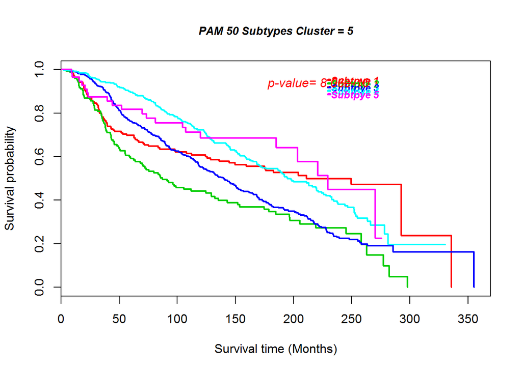

```r
#MBR_PAM50$subtype[1:20]

#KM curves for PAM50 from genefu with overall survival:
p_MBR_PAM50 = survAnalysis(mainTitle = "PAM 50 Subtypes", time = MBR_time, status = MBR_status, group = MBR_PAM50$subtype)
```

```
##
## PAM 50 Subtypes Relapse free Cluster= 5   Call:
## survdiff(formula = Surv(time, status) ~ group)
##
##                N Observed Expected (O-E)^2/E (O-E)^2/V
## group=Basal  172       62     54.6     1.017     1.172
## group=Her2   149       71     38.5    27.447    30.257
## group=LumB   510      189    166.6     3.025     5.008
## group=LumA   395       85    144.5    24.483    37.349
## group=Normal  57       15     17.9     0.478     0.499
##
##  Chisq= 56.6  on 4 degrees of freedom, p= 1.49e-11
```

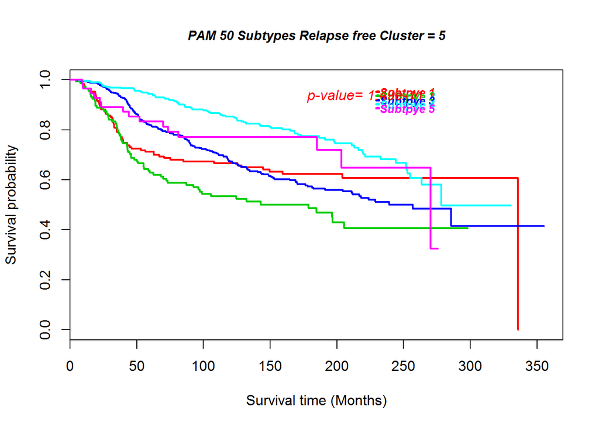

```r
# KM curves for PAM50 from genefu with disease relapse free time:
p_MBR_RF_PAM50 = survAnalysis(mainTitle = "PAM 50 Subtypes Relapse free", time = MBR_RF_time, status = MBR_RF_status, group = MBR_PAM50$subtype)
```

```
##
## PAM 50 Subtypes (from METABRIC) Cluster= 6   Call:
## survdiff(formula = Surv(time, status) ~ group)
##
##                N Observed Expected (O-E)^2/E (O-E)^2/V
## group=Basal  209      100   111.50     1.187     1.407
## group=Her2   127       89    59.48    14.650    16.272
## group=LumA   479      255   296.44     5.793     9.864
## group=LumB   312      202   168.56     6.635     8.670
## group=NC       5        4     3.14     0.236     0.238
## group=Normal 151       72    82.88     1.429     1.618
##
##  Chisq= 30.3  on 5 degrees of freedom, p= 1.28e-05
```

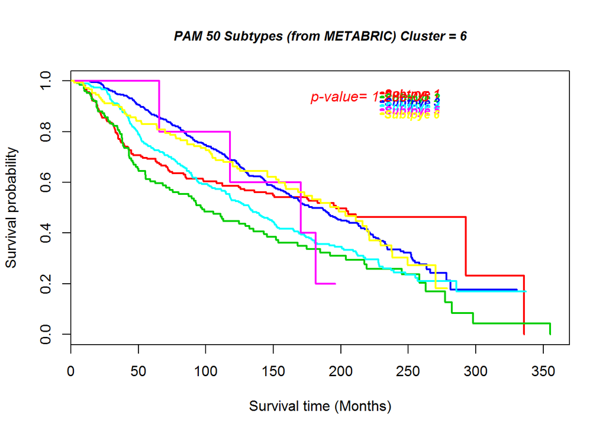

```r
#KM curves for PAM50 done by Metabric with overall survival:
p_MBR_PAM50_existing = survAnalysis(mainTitle = "PAM 50 Subtypes (from METABRIC)", time = MBR_time, status = MBR_status, group = MBR_clin$Pam50_SUBTYPE)
```

```
##
## PAM 50 Subtypes (from METABRIC) Relapse free Cluster= 6   Call:
## survdiff(formula = Surv(time, status) ~ group)
##
##                N Observed Expected (O-E)^2/E (O-E)^2/V
## group=Basal  209       79    64.06   3.48602   4.11848
## group=Her2   127       56    34.82  12.88471  14.08704
## group=LumA   479      110   172.40  22.58618  38.30017
## group=LumB   312      129    99.63   8.65855  11.34534
## group=NC       5        2     1.88   0.00781   0.00785
## group=Normal 151       46    49.22   0.21005   0.23816
##
##  Chisq= 48.1  on 5 degrees of freedom, p= 3.43e-09
```

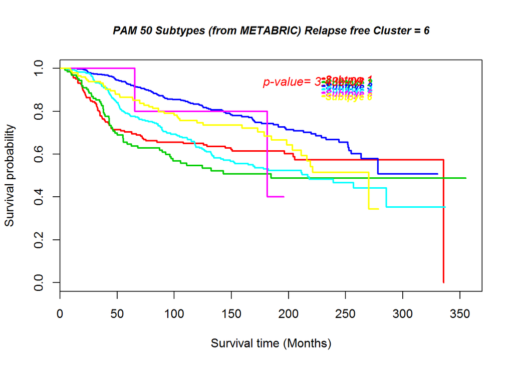

```r
#KM curves for PAM50 done by Metabric with disease relapse free time:
p_MBR_RF_PAM50_existing = survAnalysis(mainTitle = "PAM 50 Subtypes (from METABRIC) Relapse free", time = MBR_RF_time, status = MBR_RF_status, group = MBR_clin$Pam50_SUBTYPE)
```

### 3.1.2 IntClust

```r
#running  intClust using genefu
MBR_intClust<-molecular.subtyping(sbt.model = "intClust",data=MBR_mRData,
                                  annot=MBR_mRNA_Anno,do.mapping=FALSE)
```

[output not shown]

```r
table(MBR_intClust$subtype)
```

```
##
##  iC1  iC2  iC3  iC4  iC5  iC6  iC7  iC8  iC9 iC10
##   92   40  198  246  118   51  113  187   95  143
```

```
##
## inclust Subtypes Cluster= 10   Call:
## survdiff(formula = Surv(time, status) ~ group)
##
##              N Observed Expected (O-E)^2/E (O-E)^2/V
## group=iC1   92       53     47.6    0.6052    0.6491
## group=iC2   40       26     20.8    1.3254    1.3733
## group=iC3  198      102    122.9    3.5512    4.2868
## group=iC4  246      122    136.7    1.5898    1.9755
## group=iC5  118       72     48.1   11.8464   12.7331
## group=iC6   51       30     30.9    0.0246    0.0258
## group=iC7  113       71     67.7    0.1619    0.1789
## group=iC8  187      114    117.9    0.1261    0.1509
## group=iC9   95       64     49.1    4.5104    4.8473
## group=iC10 143       68     80.3    1.8909    2.1383
##
##  Chisq= 25.7  on 9 degrees of freedom, p= 0.00225
```

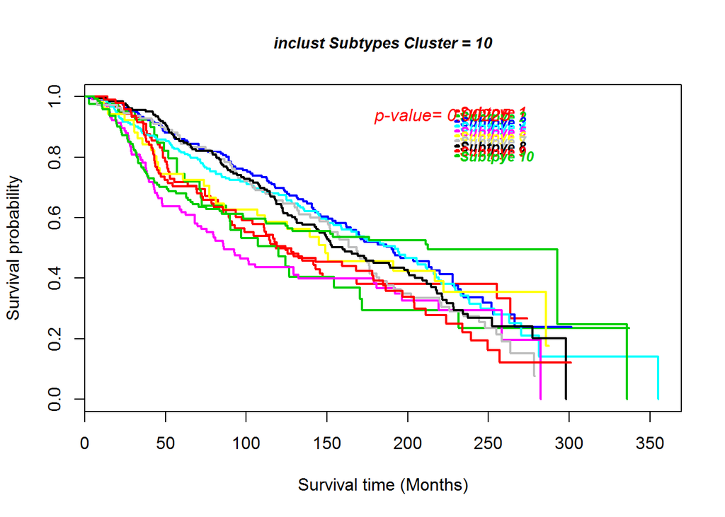

```r
#MBR_intClust$subtype[1:20]

#KM curves for intClust from genefu with overall survival:
p_MBR_inclust = survAnalysis(mainTitle = "inclust Subtypes", time = MBR_time, status = MBR_status, group = MBR_intClust$subtype)
```

```
##
## intClust Subtypes Relapse free Cluster= 10   Call:
## survdiff(formula = Surv(time, status) ~ group)
##
##              N Observed Expected (O-E)^2/E (O-E)^2/V
## group=iC1   92       35     28.3     1.602     1.719
## group=iC2   40       20     12.6     4.362     4.534
## group=iC3  198       46     71.3     8.969    10.806
## group=iC4  246       70     80.2     1.296     1.602
## group=iC5  118       52     29.5    17.101    18.437
## group=iC6   51       20     17.6     0.323     0.338
## group=iC7  113       32     39.3     1.368     1.510
## group=iC8  187       51     68.4     4.426     5.288
## group=iC9   95       45     29.3     8.357     8.991
## group=iC10 143       51     45.4     0.680     0.765
##
##  Chisq= 48.7  on 9 degrees of freedom, p= 1.92e-07
```

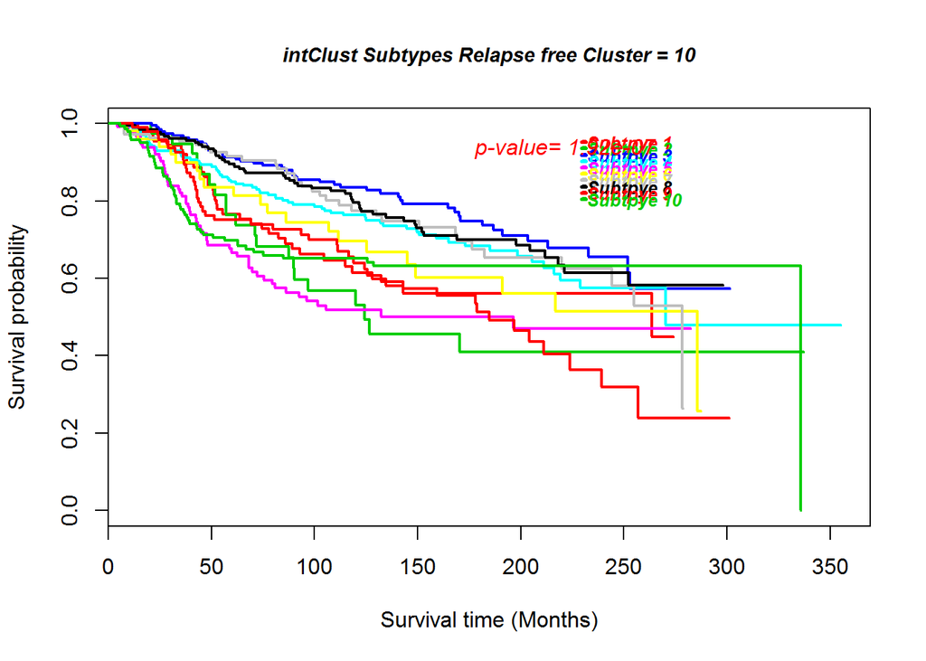

```r
#KM curves for intClust from genefu with disease relapse free time:
p_MBR_RF_inclust = survAnalysis(mainTitle = "intClust Subtypes Relapse free", time = MBR_RF_time, status = MBR_RF_status, group = MBR_intClust$subtype)
```

```
##
## intClust Subtypes (from METABRIC) Cluster= 11   Call:
## survdiff(formula = Surv(time, status) ~ group)
##
##              N Observed Expected (O-E)^2/E (O-E)^2/V
## group=1     91       52     47.2   0.48639   0.52115
## group=10   136       61     80.4   4.66528   5.30800
## group=2     52       35     30.7   0.59358   0.64268
## group=3    189       97    119.2   4.12876   4.95467
## group=4ER-  60       31     29.2   0.11276   0.11768
## group=4ER+ 191       95    108.6   1.70592   2.01080
## group=5    125       81     47.7  23.20957  24.96408
## group=6     55       34     32.0   0.13133   0.13766
## group=7    112       67     68.8   0.04702   0.05208
## group=8    185      113    113.7   0.00435   0.00518
## group=9     87       56     44.5   2.94533   3.14269
##
##  Chisq= 38.3  on 10 degrees of freedom, p= 3.38e-05
```

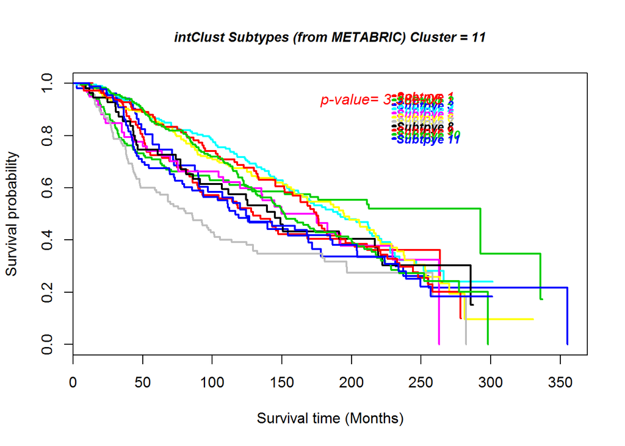

```r
#KM curves for intClust done by Metabric with overall survival:
p_MBR_intClust_existing = survAnalysis(mainTitle = "intClust Subtypes (from METABRIC)", time = MBR_time, status = MBR_status, group = MBR_clin$INTCLUST)
```

```
##
## intClust Subtypes (from METABRIC) Relapse free Cluster= 11   Call:
## survdiff(formula = Surv(time, status) ~ group)
##
##              N Observed Expected (O-E)^2/E (O-E)^2/V
## group=1     91       34     28.2   1.20829    1.2959
## group=10   136       45     45.3   0.00141    0.0016
## group=2     52       25     17.5   3.17425    3.3311
## group=3    189       38     69.2  14.03282   16.8087
## group=4ER-  60       19     17.4   0.15462    0.1614
## group=4ER+ 191       53     63.9   1.86976    2.2060
## group=5    125       62     29.6  35.31283   38.1242
## group=6     55       22     18.5   0.65637    0.6874
## group=7    112       30     39.6   2.34476    2.5907
## group=8    185       55     66.4   1.95966    2.3280
## group=9     87       39     26.4   6.02660    6.4343
##
##  Chisq= 67  on 10 degrees of freedom, p= 1.66e-10
```

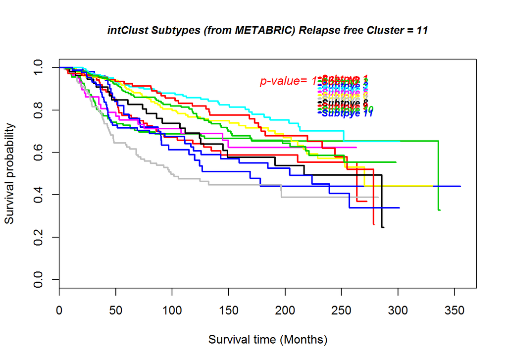

```r
#KM curves for intClust done by Metabric with disease relapse free time:
p_MBR_RF_intClust_existing = survAnalysis(mainTitle = "intClust Subtypes (from METABRIC) Relapse free", time = MBR_RF_time, status = MBR_RF_status, group = MBR_clin$INTCLUST)
```

### 3.1.3 Consensus clustering

```r
#Average the expression of each miRNA over the probes of the same miRNA symbol, or keep the probe that is more variant.
# Get matched samples of miRNA, mRNA, clinical

data=t(MBR_mRData)
##use the median to impute the missing values
data1=data.imputation(data, fun = "median")
METABRIC_CC=ExecuteCC(clusterNum=5,d=data1,maxK=5,clusterAlg="hc",distance="pearson",title="METABRIC_CC")
```

```
## end fraction
```

```
## clustered
## clustered
## clustered
## clustered
```

```r
table(METABRIC_CC$group)
```

```
##
##    1    2    3    4    5
## 1277    3    1    1    1
```

```r
##Comments: the RNAseq data (before nomalization) always return very extreme result. This is maily caulsed by the outlier
##and the Mean-Shift amony samples.

## data nomalization
data2=data.normalization(data1)
METABRIC_CC=ExecuteCC(clusterNum=5,d=data2,maxK=5,clusterAlg="hc",distance="pearson",title="METABRIC_CC")
```

```
## end fraction
## clustered
## clustered
## clustered
## clustered
```

```r
table(METABRIC_CC$group)
```

```
##
##   1   2   3   4   5
## 300 552  55 371   5
```

```r
## feature selction and nomalization
data3=FSbyMAD(data1, cut.type = "topk", 12000)
```

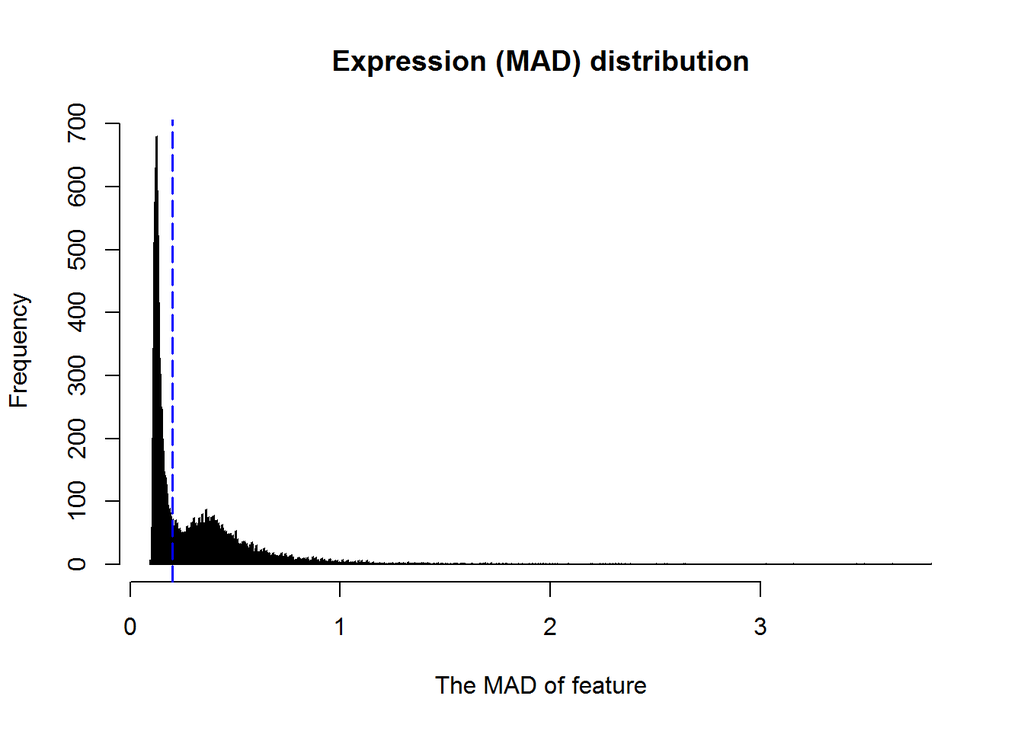

```r
data4=data.normalization(data3)
METABRIC_CC=ExecuteCC(clusterNum=5,d=data4,maxK=5,clusterAlg="hc",distance="pearson",title="METABRIC_CC")
```

```
## end fraction
## clustered
## clustered
## clustered
## clustered
```

```r
table(METABRIC_CC$group)
```

```
##
##   1   2   3   4   5
## 315 538  65 360   5
```

```
##
## CC Subtypes (overall) Cluster= 5   Call:
## survdiff(formula = Surv(time, status) ~ group)
##
##           N Observed Expected (O-E)^2/E (O-E)^2/V
## group=1 315      134   185.82    14.449     19.54
## group=2 538      348   321.15     2.245      4.07
## group=3  65       43    32.18     3.636      3.81
## group=4 360      193   180.66     0.843      1.13
## group=5   5        4     2.19     1.492      1.50
##
##  Chisq= 22.7  on 4 degrees of freedom, p= 0.000143
```

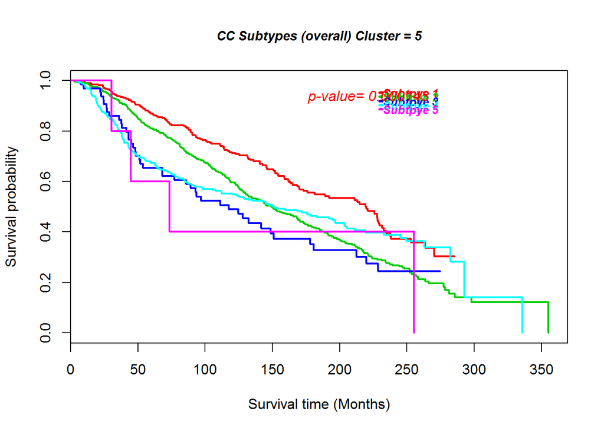

```r
#KM curves for CC from CancerSubtypes with overall survival:
p_MBR_CC = survAnalysis(mainTitle = "CC Subtypes (overall)",
                                          time = MBR_time, status = MBR_status, group = METABRIC_CC$group)
```

```
##
## CC Subtypes Relapse free Cluster= 5   Call:
## survdiff(formula = Surv(time, status) ~ group)
##
##           N Observed Expected (O-E)^2/E (O-E)^2/V
## group=1 315       74   109.37     11.44     15.49
## group=2 538      170   186.10      1.39      2.50
## group=3  65       35    19.13     13.16     13.80
## group=4 360      140   106.07     10.85     14.51
## group=5   5        3     1.32      2.16      2.16
##
##  Chisq= 39.1  on 4 degrees of freedom, p= 6.79e-08
```

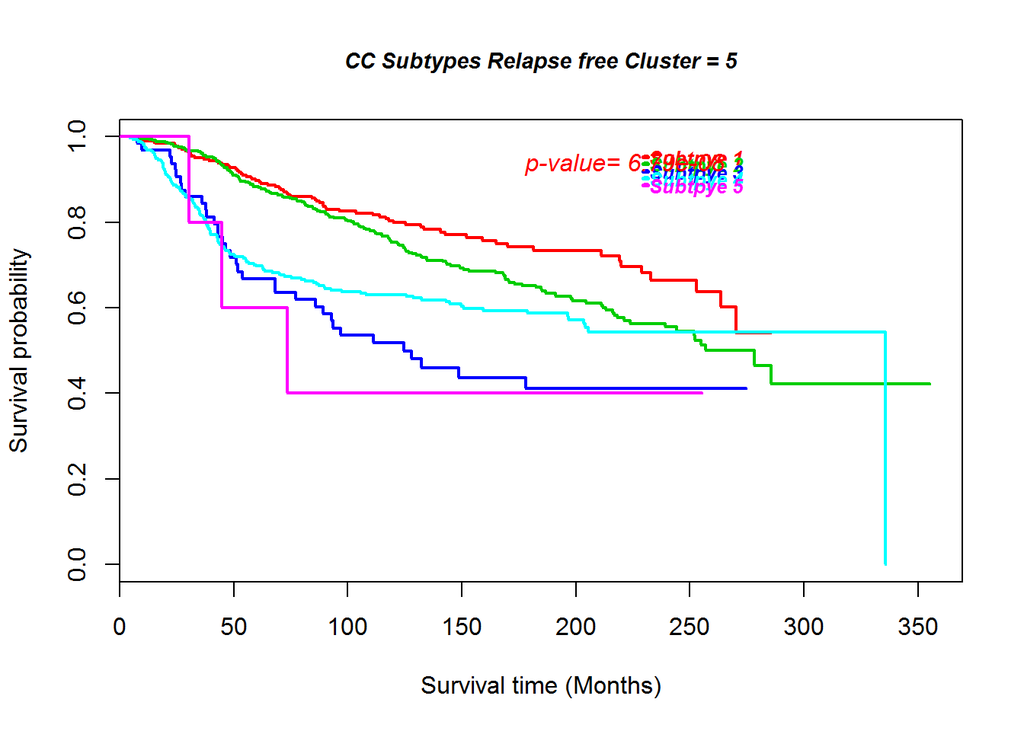

```r
# KM curves for PAM50 from genefu with disease relapse free time:
p_MBR_RF_CC = survAnalysis(mainTitle = "CC Subtypes Relapse free",
                              time = MBR_RF_time, status = MBR_RF_status, group = METABRIC_CC$group)
```